# 20182_M2.955_PAC2-Joe_v06

[figure not shown]

M2.955 · Models avançats de mineria de dades · PAC2

2018-2 · Màster universitari en Ciència de dades (Data science)

Estudis de Informàtica, Multimèdia i Telecomunicació

# PAC 2: Mètodes no supervisats

Al llarg d'aquesta pràctica veurem com aplicar diferents tècniques no supervisades així com algunes de les seves aplicacions reals:

1. **Clustering clàssic**: k-means i la regla del colze.
- **Clustering amb formes i feature engineering**
- **Reducció de dimensionalitat**: PCA i t-SNE.
- **Aplicació**: Agrupació de documents

Per a això necessitarem les següents llibreries:

```python
import random

import numpy as np
import pandas as pd
from sklearn import cluster      # Algorismes de clustering
from sklearn import datasets     # Crear datasets

# Visualitzacio
import matplotlib.pyplot as plt
import seaborn as sns

%matplotlib inline
```

## 1. Clustering clàssic: k-means i la regla del colze (2 punts)

Anem a generar un dataset compost per $n$ núvols de punts, on $n$ serà un nombre aleatori entre 2 i 4, usant el mòdul `datasets` de scikit-learn.

```
Hi ha 1500 punts en 2 dimensions (repartits en 3 clusters)
```

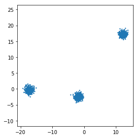

```python
N_SAMPLES = 1500
MIN_CLUSTERS = 2
MAX_CLUSTERS = 4
X, y = datasets.make_blobs(n_samples=N_SAMPLES, # Nombre de punts
                           n_features=2,        # Nombre de dimensions
                           centers=random.randint(MIN_CLUSTERS, MAX_CLUSTERS),
                           center_box=(-20, 20),
                           cluster_std=.6)
print('Hi ha {} punts en {} dimensions (repartits en {} clusters)'.format(X.shape[0], X.shape[1], y.max() + 1))
fig, ax = plt.subplots(1, 1, figsize=(4, 4))
ax.scatter(X[:,0], X[:,1], s=2)
ax.axis('equal')
plt.tight_layout()
```

Una tècnica per estimar $k$ és, com s'explica a la teoria:

> Els criteris anteriors (minimització de distàncies intra grup o maximització de distàncies inter grup) poden usar-se per establir un valor adequat per al paràmetre k. Valors k per als quals ja no s'aconsegueixen millores significatives en l'homogeneïtat interna dels segments o l'heterogeneïtat entre segments diferents, haurien de descartar-se.

El que popularment es coneix com *regla del colze*.

Primer cal calcular la suma dels errors quadràtics ([*SSE*](https://bl.ocks.org/rpgove/0060ff3b656618e9136b)) que consisteix en la suma de tots els errors (distància de cada punt al seu centroide assignat) al quadrat.

$$SSE = \sum_{i=1}^{K} \sum_{x \in C_i} euclidean(x, c_i)^2$$

On $K$ és el nombre de clusters a buscar per *k-means*, $x \in C_i$ són els punts que pertanyen al i-èsim cluster, $c_i$ és el centroide del cluster $C_i$ (al qual pertanty el punt $x$), i $euclidean$ és la [distància euclídea](https://en.wikipedia.org/wiki/Euclidean_distance).

Aquest procediment realitzat per a cada possible valor $k$, resulta en una funció monòtona decreixent, on l'eix $x$ representa els diferents valors de $k$, i l'eix $y$ el $SSE$. Intuïtivament es podrà observar un significatiu descens de l'error, que indicarà el valor idoni de $k$.

**Es demana realitzar la representació gràfica de la regla del colze al costat de la seva interpretació, utilitzant la llibreria `matplotlib` i la implementació en scikit-learn de [*k-means*](http://scikit-learn.org/stable/modules/generated/sklearn.cluster.KMeans.html).**

**Implementació:** càlcul i visualització de la regla del colze.

```python
from sklearn.cluster import KMeans         # Algoritme k-means

# Llista amb els valors de k amb els que s'implementara k-means
k = [1, 2, 3, 4, 5, 6, 7, 8, 9]

def kmeans_kolze (k_array,X):
    """
    Implementacio de l'aplicació de l'algoritme k-means a una matriu de dades (X), per diferents valors de k (k_array)

    Arguments:
    k_array -- llista amb els valors de k a emprar
    X -- matriu de dades: (numero de punts, dimensions dels punts)

    Retorna:
    SSE_array -- una llista amb els SSE associats a aplicar l'algoritme k-means a X per cada valor de k dins k_array
    """
    # Inicialitza la llista on s'emmagatzemaran els SSE per cada valor k
    SSE_array = []

    # Implementa k-means per a tots els valors de k dins k_array
    for k in k_array:
        kmeans = KMeans(n_clusters=k)                 # Inicialitza el model amb el parametre corresponent
        kmeans.fit(X)                                 # Calcula el model amb les dades inicials (X)
        y_kmeans = kmeans.predict(X)                  # Assigna a les dades inicials el cluster segons el model calculat
        centroides = kmeans.cluster_centers_          # Retorna els centroides dels clusters calculats

        # Calcula la suma dels errors quadratics (SSE)
        SSE_temp = 0
        for i in range(k):
            SSE_temp += np.sum((X[y_kmeans==i]-centroides[i])**2)

        SSE_array.append(SSE_temp)

    return SSE_array

SSE = kmeans_kolze (k,X)
```

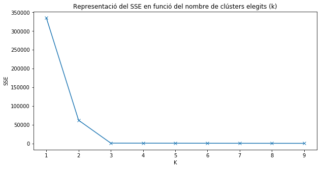

```python
# Visualitzacio de la relacio entre SSE i k
plt.figure(figsize=(10,5))
plt.plot(k,SSE,marker="x")
plt.xticks(k)
plt.xlabel("K")
plt.ylabel("SSE")
plt.title("Representació del SSE en funció del nombre de clústers elegits (k)");
```

**Anàlisi:** Què s'interpreta en la gràfica? Com podria millorar-se l'elecció de $k$?

Es pot observar com el valor de la suma dels errors quadràtics disminueix com més gran és k. Aquesta disminució és més gran al principi, però arriba un moment on no és tan gran i s'estanca, és a dir, el gràfic s'aplana i agafa la forma anomenada de "colze". Aquest seria el valor de k idoni, que caldria agafar segons la regla del colze

**[OPCIONAL] Implementació:** algorisme *k-means* des de zero.

```python
def kmeans_joe (X, n_clusters, max_iter=300, verbose=0):
    """
    Implementacio manual de l'algoritme k-means a una matriu de dades (X), per un determinat valor de k (n_clusters)

    Arguments:
    X -- matriu de dades: (numero de punts, dimensions dels punts)
    n_cluster -- integer>0 amb el valor del nombre de clusters a estudiar (k)
    max_iter -- integer>0 amb el valor maxim d'iteracions que es realitzaran
    verbose -- 0 (default) -> no mostrar cap resultat per pantalla
               1 -> mostra els centroides inicials i intermitjos (temporals), aixi com el nombre d'iteracions total

    Retorna:
    y_labels -- np.array amb les etiquetes resultat d'aplicar el metode (numero de punts,)
    centroids -- np.array amb els 'k' centroides resultat d'aplicar el metode (n_clusters, dimensions dels punts)
    SSE -- float amb el valor de la suma dels valors quadratics
    """
    # Inicialitza els centroides agafant aleatoriament 'k'(n_clusters) punts inicials
    random_positions = np.random.randint(X.shape[0], size=n_clusters)
    centroids = X[random_positions,:]

    if verbose==1:
        print("-"*100)
        print("Calculant l'algoritme k-means (k={}) per {} dades de {} dimensions\n"
              .format(n_clusters, X.shape[0], X.shape[1]))
        print("centroides inicials:\n", centroids,"\n")

    # Inicialitza el vector d'etiquetes i els centroides temporals
    y_labels = np.zeros(X.shape[0])
    centroids_temp=np.zeros((n_clusters, X.shape[1]))
    iteration = 1

    while True:
        # Per cada punt, assigna el centroide mes proper
        for i, point in enumerate(X):
            y_labels[i] = np.argmin(np.sum((centroids-point)**2, axis=1))

        # Recalcula els centroides
        for i in range(n_clusters):
            centroids_temp[i] = np.sum(X[y_labels==i], axis=0)/X[y_labels==i].shape[0]

        if verbose==1:
            print("centroides temporals:\n", centroids_temp)

        # Comprova convergencia per calcular l'SSE i aturar l'algoritme, en cas contrari torna a asignar nous centroides
        if ((centroids_temp == centroids).all()) or iteration == max_iter:
            SSE = 0
            for i in range(n_clusters):
                SSE += np.sum((X[y_labels==i]-centroids[i])**2)

            if verbose==1:
                print("\n--> Algoritme aturat després de {} iteracions".format(iteration))
                print("-"*100)

            break
        else:
            centroids = centroids_temp
            iteration += 1

    return y_labels, centroids, SSE

# Aplica l'algoritme a la matriu de dades inicials mostrant resultats per pantalla (verbose=1)
y_kmeans_joe, centroids, SSE = kmeans_joe(X, 2, verbose=1)

# Mostra el resultat de l'algoritme
print("Els centroides finals són:\n{}\n\nEl valor de la suma dels errors quadràtics (SSE) és {:0.3f}"
      .format(centroids, SSE))
```

```
----------------------------------------------------------------------------------------------------
Calculant l'algoritme k-means (k=2) per 1500 dades de 2 dimensions

centroides inicials:
 [[-1.59460977 -1.77673277]
 [-2.46692141 -2.29501064]]

centroides temporals:
 [[  7.83384356  11.05604258]
 [-12.10256198  -1.13353346]]
centroides temporals:
 [[12.15504256 17.23133169]
 [-9.59804259 -1.36881722]]

--> Algoritme aturat després de 2 iteracions
----------------------------------------------------------------------------------------------------
Els centroides finals són:
[[12.15504256 17.23133169]
 [-9.59804259 -1.36881722]]

El valor de la suma dels errors quadràtics (SSE) és 62154.244
```

En aquest cas, amb 2 dimensions, és molt senzill inferir el nombre de clústers visualitzant les dades. Però aquest mètode és de gran utilitat quan es compta amb dades d'alta dimensionalitat.

## 2. Clustering amb formes i feature engineering (4 punts)

Però no tots els datasets són com els de l'exercici anterior. Per a aquesta segona part anem a emprar el conjunt de dades següent:

```python
data_circles = ('circles', *datasets.make_circles(n_samples=N_SAMPLES, factor=.5, noise=.05))
```

On *data_circles* és una tupla amb tres posicions: el nom del dataset i els dos valors retornats per la funció que genera el dataset:

```python
datasets.make_circles?
```

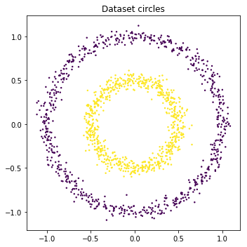

```python
fig, ax = plt.subplots(1, 1, figsize=(5, 5))
ax.scatter(data_circles[1][:,0], data_circles[1][:,1], c=data_circles[2], s=2)
ax.set_title('Dataset {}'.format(data_circles[0]))
plt.tight_layout()
```

### 2 a. Trobant els clusters amb *k-means*

**Implementació:** aplica la regla del colze per decidir el valor de $k$ en aquest dataset.

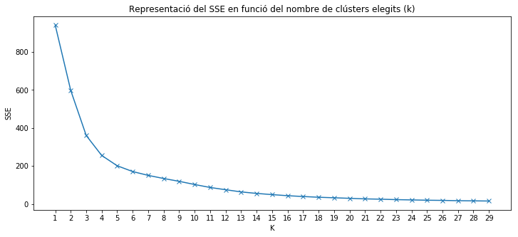

```python
# Creacio de la llista de valors 'k' amb els que s'aplicara l'algoritme k-means [1-29]
k = range(1,30)

# Crida a la funcio creada anteriorment per tal de calcular els SSE associats per cada k
SSE = kmeans_kolze(k,data_circles[1])

# Visualitzacio de la relacio entre SSE i k
plt.figure(figsize=(12,5))
plt.plot(k,SSE,marker="x")
plt.xticks(k)
plt.xlabel("K")
plt.ylabel("SSE")
plt.title("Representació del SSE en funció del nombre de clústers elegits (k)");
```

S'observa que el gràfic no té una forma de colze clara, amb una diferencia clàra de canvi de pendents, en canvi, presenta un colze "arrodonit" dificultant l'elecció del valor de k idoni.

**Implementació:** aplica *k-means* amb el valor de $k$ escollit per aquest dataset.  
Visualitza el resultat en un *scatter plot* representant cada clúster amb un color diferent.

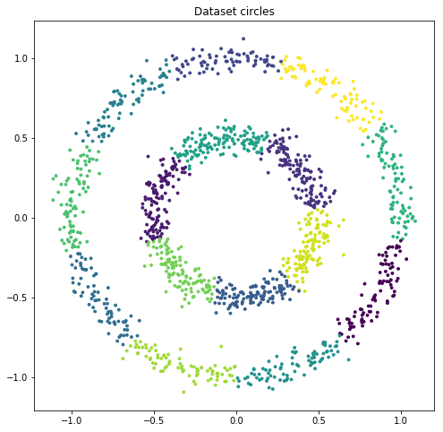

```python
k_kolze = 15
kmeans = KMeans(n_clusters=k_kolze)           # Inicialitza el model amb el parametre corresponent
kmeans.fit(data_circles[1])                   # Calcula el model amb les dades (data_circles)
y_kmeans = kmeans.predict(data_circles[1])    # Assigna a les dades inicials el cluster segons el model calculat
centroides = kmeans.cluster_centers_          # Retorna els centroides dels clusters calculats

# Visualitza els clusters amb colors diferents
fig, ax = plt.subplots(1, 1, figsize=(8, 8))
ax.scatter(data_circles[1][:,0], data_circles[1][:,1], c=y_kmeans, s=8)
ax.set_title('Dataset {}'.format(data_circles[0]));
```

**Anàlisi:** Què ha passat? Explica els motius pels quals creus que s'ha produït aquest resultat.

Per la pròpia definició del mètode k-means, aquest funciona bé quan la separació entre els diferents clústers és lineal. En l'exemple del dataset "circles" la frontera dels dos clústers és una circumferència i, per tant, era d'esperar que no tingués un bon comportament. De fet el gràfic SSE/k ja ens ha avisat que els clúster obtinguts podrien tenir problemes quan no indicava clárament el colze.

Si es representen els centroides obtinguts del mètode k-means per a k=15 (figura mostrada en el quadre de codi següent, on els diferents centroides s'han indicat amb estrelles) es pot observar com els diferents centroides es van distribuint al llarg dels dos anells de dades, però no s'aconsegueix agrupar correctament els dos grups.

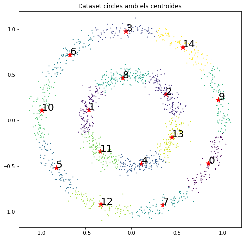

```python
# Visualitza els diferents clusters i es mostren els centroides associats
fig, ax = plt.subplots(1, 1, figsize=(8, 8))
for i, centroid in enumerate(centroides):
    ax.annotate(i, centroid, size=20)
ax.scatter(centroides[:,0], centroides[:,1], marker="*", s=100, c="red")
ax.scatter(data_circles[1][:,0], data_circles[1][:,1], c=y_kmeans, s=1)
ax.axis("equal")
ax.set_title('Dataset {} amb els centroides'.format(data_circles[0]));
```

### 2 b. Més enllà de *k-means*: algorismes basats en la densitat

En aquest apartat es demana aplicar clustering per densitat com DBSCAN al dataset anterior per trobar els dos clusters inicials.

**Implementació:** Prova la implementació de [DBSCAN en scikit-learn](http://scikit-learn.org/stable/modules/generated/sklearn.cluster.DBSCAN.html) jugant amb els paràmetres *eps* i *min_samples* per trobar les 2 estructures subjacents (i *outliers*).

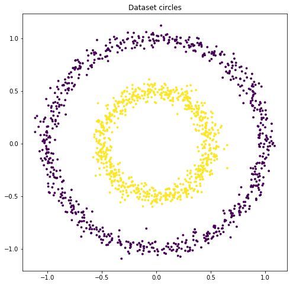

```python
from sklearn.cluster import DBSCAN             # Algoritme DBSCAN

dbscan=DBSCAN(eps=0.15)                        # Inicialitza el model amb el parametre corresponent
y_dbscan=dbscan.fit_predict(data_circles[1])   # Calcula el model i realitza a les dades inicials l'agrupament

# Visualitza els clusters amb colors diferents
fig, ax = plt.subplots(1, 1, figsize=(8, 8))
ax.scatter(data_circles[1][:,0], data_circles[1][:,1], c=y_dbscan, s=8)
ax.set_title('Dataset {}'.format(data_circles[0]));
```

```python
# Es comprova l'exactitud de l'agrupacio
accuracy = sum(data_circles[2]==y_dbscan)/len(y_dbscan)*100
print("L'exactitud de l'agrupament amb el mètode DBSCAN és del {:.2f}%.".format(accuracy))
```

```
L'exactitud de l'agrupament amb el mètode DBSCAN és del 100.00%.
```

**Anàlisi:** Què ha passat? Explica els motius pels quals creus que s'ha produït aquest resultat.

El model DBSCAN basat en l'agrupament per densitats, una vegada ajustats els paràmetres del model, és capaç d'agrupar correctament les dades, cosa que amb el model k-means no era possible. Això és degut a que el model basat en densitats no li afecta quina és la frontera dels clústers.

### 2 c. Més enllà de *k-means*: algorismes jeràrquics

En aquest apartat es demana visualitzar mitjançant un [dendrograma](https://en.wikipedia.org/wiki/Dendrogram) la construcció progressiva dels grups mitjançant un algoritme jeràrquic aglomeratiu (estratègia *bottom-up*). Amb això es pretén trobar un mètode gràfic per determinar el nombre de clústers en cada escenari.

**Implementació:** Prova la implementació de [clustering jeràrquic de scipy](https://docs.scipy.org/doc/scipy/reference/cluster.hierarchy.html) amb diferents [criteris d'enllaç o *linkage*](https://en.wikipedia.org/wiki/Hierarchical_clustering#Linkage_criteria) permetent identificar els clusters subjacents (mostrant el seu resultat) i el seu dendrograma

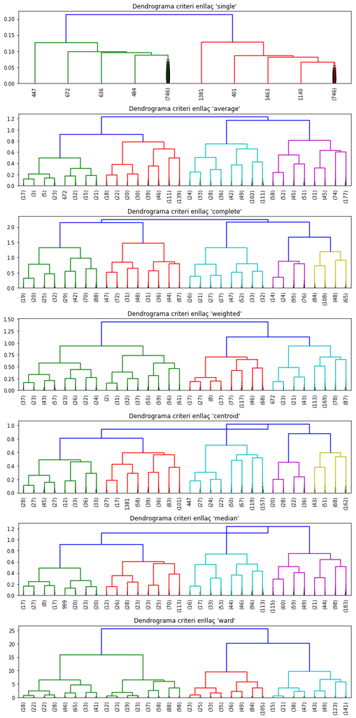

```python
from scipy.cluster.hierarchy import linkage         # linkage realitza la clusteritzacio jerarquica
from scipy.cluster.hierarchy import dendrogram      # dendrogram dibuixa el dendrograma d'una clusteritzacio jerarquica
from scipy.cluster.hierarchy import fcluster        # fcluster aplana un cluster a partir d'una matriu d'enllac

# Crea la llista amb tots els criteris d'enllac a utilitzar
linkage_methods=["single","average","complete","weighted","centroid","median","ward"]
# Diccionari on s'emmagatzemaran les diferents clusteritzacions jerarquiques com matrius d'enllac
hierar_clusters = {}

# Visualitza els dendrogrames per cada criteri d'enllac mostrant fins al nivell 4
fig, axes = plt.subplots(len(linkage_methods),1, figsize=(10, 20))
for i, method in enumerate(linkage_methods):
    axes[i].set_title("Dendrograma criteri enllaç '{}'".format(method))
    hierar_clusters[method] = linkage(data_circles[1],method=method)
    dendrogram(hierar_clusters[method],leaf_rotation=90,leaf_font_size=10,
               truncate_mode="level",p=4,show_contracted=True,ax=axes[i])
plt.tight_layout()
plt.show()
```

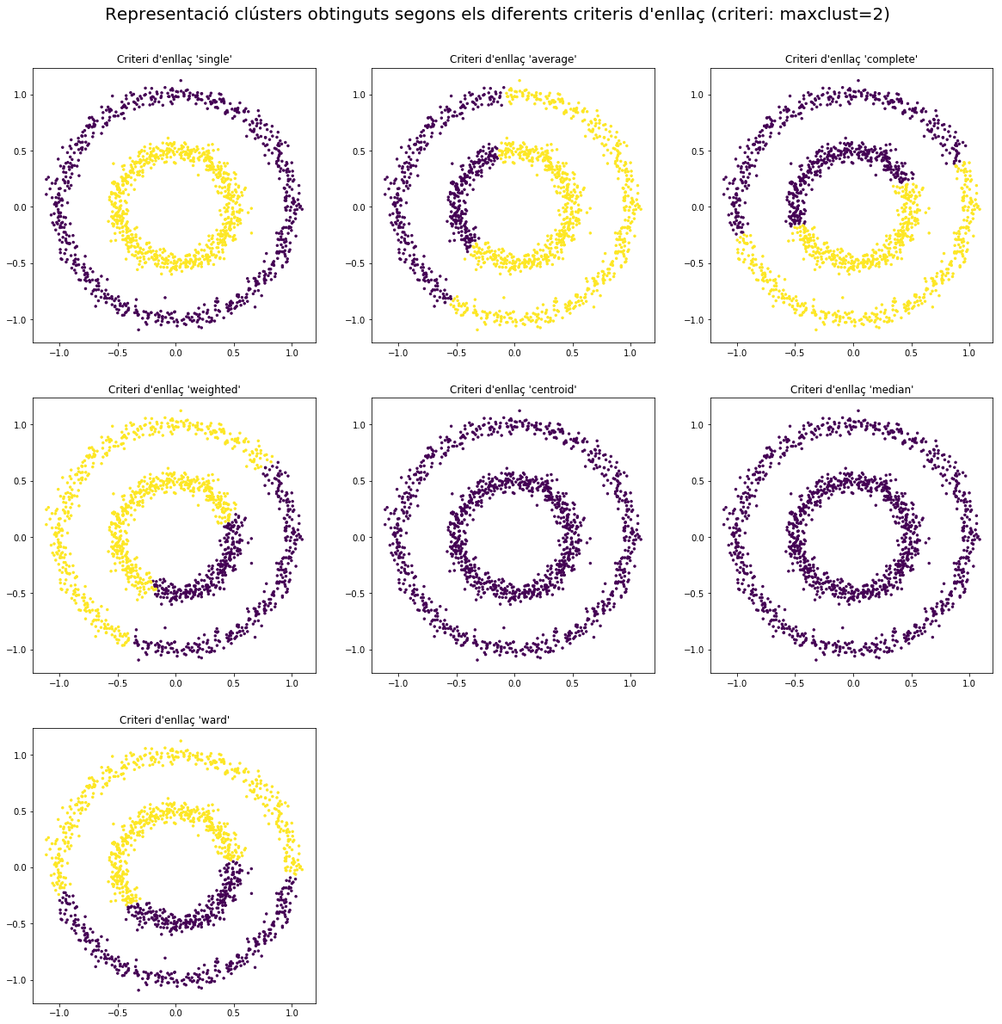

```python
# Visualitza els clusters amb colors diferents per cada criter d'enllac
fig = plt.figure(figsize=(20,20))
fig.suptitle("Representació clústers obtinguts segons els diferents criteris d'enllaç (criteri: maxclust=2)",
             x=0.5, y=0.93, fontsize=20)
fig.subplots_adjust(hspace=0.2, wspace=0.2)

for i, method in enumerate(linkage_methods):
    y_hierar=fcluster(hierar_clusters[method],2,criterion="maxclust")

    plt.subplot(3,3,i+1)
    plt.title("Criteri d'enllaç '{}'".format(method))
    plt.scatter(data_circles[1][:,0], data_circles[1][:,1], c=y_hierar, s=6)
```

**Anàlisi:** Interpreta el dendrograma i comenta quin criteri d'enllaç es comporta millor. Per què?

Analitzant el dendrograma, s'observa que el criteri d'enllaç que es comporta millor és el 'single', ja que és el que presenta un major salt de distàncies en l'agrupament dels dos clústers, en comparació amb la resta d'agrupaments anteriors. Aquest millor comportament es comfirma també gràficament per l'agrupació realitzada mostrada en les figures anteriors, on s'observa que el criteri d'enllaç 'single' és capaç d'agrupar correctament els dos grups existents de dades (cap altre criteri d'enllaç és capaç de fer-ho).

El motiu d'aquest millor comportament és degut a la geometria de les dades a agrupar i la definició d'enllaç simple, ja que intenta agrupar clústers seguint el criteri d'agrupar els clústers amb la distància mínima entre elements, així, amb aquesta geometria de dades, seguint un dels cercles de dades, sempre es prioritzarà agrupar els punts més propers, és a dir, els que estan dins el mateix cercle de dades i, en canvi, les dades de l'altre anell quedaran lluny, aquestes altres dades, també s'agruparan entre elles. Fins al final on s'agruparan els dos clústers, per formar el cluster únic de totes les dades, però això sí, incrementant la distància a la que es troben els dos clústers respecte a la distància de les agrupacions realitzades anteriorment entre clústers del mateix anell de dades, tal com es mostra en el dendrograma.

**Anàlisi:** Què ha passat? Explica els motius pels quals creus que s'ha produït aquest resultat.

Tal com s'observa als dendrogrames i a les figures anteriors de la representació gràfica del resultat de l'agrupament segons el criteri d'enllaç utilitzat, suposant l'"aplanament" del clúster sota el criteri maxclust=2, l'únic criteri d'enllaç que és capaç d'agrupar correctament les dades és el 'single'. La resta de criteris agrupen les dades incorrectament i, fins i tot, amb el criteri 'centroid' no s'és capaç de trobar dos clústers de dades.

Aquest resultat s'explica per la distribució de les dades a clusteritzar i per la pròpia definició dels diferents criteris d'enllaç, així, per exemple, que no es pugui obtenir dos clústers diferenciats amb el criteri 'centroid' és degut a que les dades inicials formen dos anells concèntrics, és a dir, amb el mateix centre i, per tant, tenen el mateix centroide, fet que fa impossible poder distinguir-les segons aquest criteri.

### 2 d. *Feature engineering* i agrupament

Alguns dels algorismes anteriors es basen en unes suposicions que no es complien en aquest dataset. Moltes vegades, enlloc d'optar per algorismes més complexes o que requereixen més poder computacional, es poden transformar les dades per a poder aplicar amb èxit les tècniques més simples. Aquest és un exemple molt clar de *feature engineering*.

**Implementació:** Transforma els punts anteriors del dataset a un nou espai de 2 dimensions:

- Radi, o distància al punt (0,0)
- Angle, respecte al vector (1,0)

Per tal que totes les dimensions tinguin el mateix pes, haurem de [normalitzar-les entre 0 i 1 d'acord amb el seu màxim i mínim](http://scikit-learn.org/stable/modules/generated/sklearn.preprocessing.MinMaxScaler.html).  
Visualitza els punts del "nou" dataset.

```python
# Fem el canvi de coordenades a polars on:
# radi >0
# -pi/2 < angle < 3*pi/2
radi = np.sqrt(np.sum(data_circles[1]**2,axis=1))
angle = np.arctan(data_circles[1][:,1]/data_circles[1][:,0])+(np.sign(data_circles[1][:,0])==-1)*np.pi

X_polar=np.vstack((radi,angle)).T
```

```python
from sklearn.preprocessing import MinMaxScaler

# Entrena i transforma les dades per tal de normalitzar-les entre 0 i 1
X_polar_scaled = MinMaxScaler().fit_transform(X_polar)
```

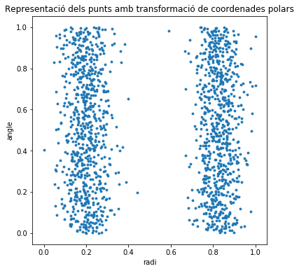

```python
# Visualitza les dades transformades i normalitzades
fig, ax = plt.subplots(1, 1, figsize=(6,6))
ax.scatter(X_polar_scaled[:,0],X_polar_scaled[:,1], s=8)
ax.set_xlabel("radi")
ax.set_ylabel("angle")
ax.set_title("Representació dels punts amb transformació de coordenades polars");
```

**Anàlisi:** Què creus que passarà a l'aplicar els algorismes anteriors a aquest "nou" dataset?

El més probable és que, utilitzant qualsevol dels criteris d'enllaç, es pugui clusteritzar sense problemes el conjunt de dades.

**Implementació:** Aplica cadascun dels algorismes d'agrupament anteriors que no han pogut identificar adequadament els dos clusters originals per tractar de trobar-los en aquest "nou" espai. Ajusta els paràmetres necessaris per facilitar la seva detecció.  
Par cada algorisme, visualitza els clusters trobats en 2 imatges:

- En el "nou" espai (radi i angle).
- En l'espai original (posició x i y), però NO amb les etiquetes (pertença a un o altre cluster) obtingudes a l'aplicar els algorismes sobre el dataset original, sinó amb les etiquetes obtingudes al realitzar el clustering en el "nou" espai. A veure si així s'aconsegueixen resoldre els problemes inicials.

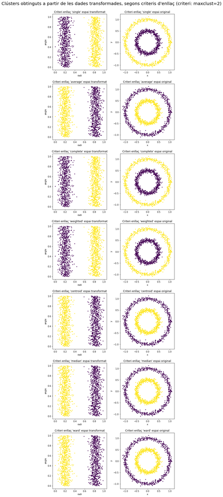

```python
# Visualitza per cada criteri d'enllac els punts en l'espai transformat i en l'espai original amb colors diferents
# segons els cluster resultant
fig, axes = plt.subplots(len(linkage_methods),2, figsize=(10, 40))
fig.suptitle("Clústers obtinguts a partir de les dades transformades, segons criteris d'enllaç (criteri: maxclust=2)",
             x=0.5, y=0.9, fontsize=20)
fig.subplots_adjust(hspace=0.25, wspace=0.25)

hierar_clusters_polar={}

for i, method in enumerate(linkage_methods):
    hierar_clusters_polar[method] = linkage(X_polar_scaled,method=method)

    y_hierar=fcluster(hierar_clusters_polar[method],2,criterion="maxclust")

    axes[i,0].set_title("Criteri enllaç '{}' espai transformat".format(method))
    axes[i,0].scatter(X_polar_scaled[:,0], X_polar_scaled[:,1], c=y_hierar, s=6)
    axes[i,0].set_xlabel("radi")
    axes[i,0].set_ylabel("angle")

    axes[i,1].set_title("Criteri enllaç '{}' espai original".format(method))
    axes[i,1].scatter(data_circles[1][:,0], data_circles[1][:,1], c=y_hierar, s=6)
    axes[i,1].set_xlabel("x")
    axes[i,1].set_ylabel("y")
```

## 3. Reducció de dimensionalitat: PCA i t-SNE (1 punt)

En plantejar un problema de classificació amb un dataset de més de tres atributs (dimensions), no es pot fer una visualització clàssica del dataset per entendre les dades. Per això, un dels usos dels mètodes de reducció de dimensionalitat és transformar les dades de més de 4 dimensions a 3 o menys per poder visualitzar-los.

### 3 a. PCA

El [dataset Iris](https://es.wikipedia.org/wiki/Iris_flor_conjunto_de_datos) conté 4 atributs sobre tres tipus de flors.

```python
iris = datasets.load_iris()
X = iris.data   # np.array amb shape (150, 4)
y = iris.target # np.array amb shape (150,)
```

En excedir les 3 dimensions necessitarem més d'una visualització per entendre les dades.

Per solucionar-ho, una alternativa és usar els [*pair plots*](http://seaborn.pydata.org/generated/seaborn.pairplot.html) que mostren parells de dimensions per intentar donar una visió global a partir d'un [DataFrame](https://pandas.pydata.org/pandas-docs/stable/dsintro.html):

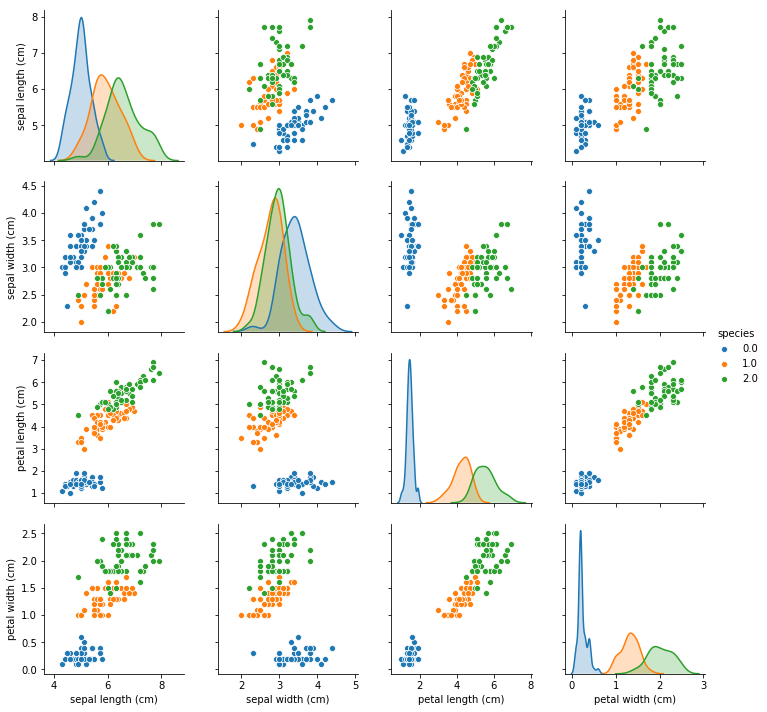

```python
# DataFrame
iris_df = pd.DataFrame(np.hstack([X, y.reshape(-1, 1)]), columns=iris.feature_names + ['species'])
sns.pairplot(iris_df, vars=iris.feature_names, hue="species")
```

Com a alternativa a les múltiples gràfiques que generen els *pair plots*, es planteja utilitzar una tècnica de reducció de dimensionalitat per passar de 4 dimensions a 2. Cal notar que gràfiques com *longitud de pètal* vs *amplada de pètal* mostren certa separabilitat (els 3 tipus de flors estan aparentment separats).

**Implementació:** Realitzar una reducció de dimensionalitat amb PCA per passar de 4 dimensions a 2 i crear una visualització on el color dels punts depengui del tipus de flor a la qual pertany.

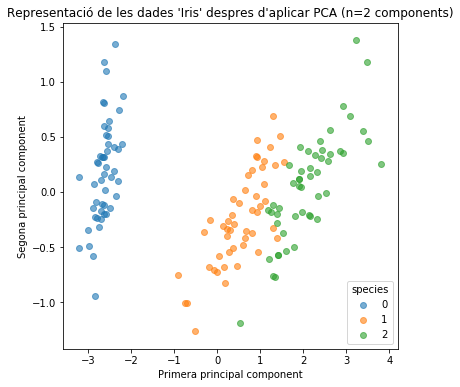

```python
from sklearn.decomposition import PCA

# Reduccio a 2 dimensions utilitzant PCA
pca = PCA(n_components=2)
X_pca = pca.fit_transform(X)

# Dibuixa el resultat d'aplicar el metode PCA
fig,ax = plt.subplots(1,1,figsize=(6,6))

for i in range(len(set(y))):
    ax.scatter(X_pca[y==i][:,0],X_pca[y==i][:,1],label=i,alpha=0.6)

ax.legend(title="species", loc=4)
ax.set_xlabel("Primera principal component")
ax.set_ylabel("Segona principal component")
ax.set_title("Representació de les dades 'Iris' despres d'aplicar PCA (n=2 components)");
```

**Anàlisi:** El resultat de la reducció de dimensionalitat manté la separabilitat? Era d'esperar? Per què?

Es pot observar com el resultat de la reducció de la dimensionalitat manté força bé la separabilitat. El resultat era d'esperar, ja que el mètode PCA agafa les principals components a les que redueix l'espai d'atributs segons les 'n' direccions de màxima variança i, com hem vist que existien determinats atributs/direccions on es les dades eren relativament separables amb una certa variança, era d'esperar que amb la transformació del mètode PCA es pogués mantenir aquesta separabilitat.

### 3 b. t-SNE (t-distributed Stochastic Neighbor Embedding)

L'ús de tècniques de reducció de dimensionalitat és de gran utilitat quan aquesta és molt alta. Per exemple, el [dataset Digits](http://scikit-learn.org/stable/auto_examples/classification/plot_digits_classification.html) conté 1797 imatges de nombres del 0 al 9, de 8 per 8 píxels. Si es pren cada píxel com una dimensió, això es tradueix en què cada mostra té 64 dimensions!

```python
digits = datasets.load_digits()
X = digits.data   # np.array amb shape (1797, 64)
y = digits.target # np.array amb shape (1797,)
```

Exemple dels 24 primers números de 8 per 8 píxels al costat de la seva etiqueta presents al dataset:

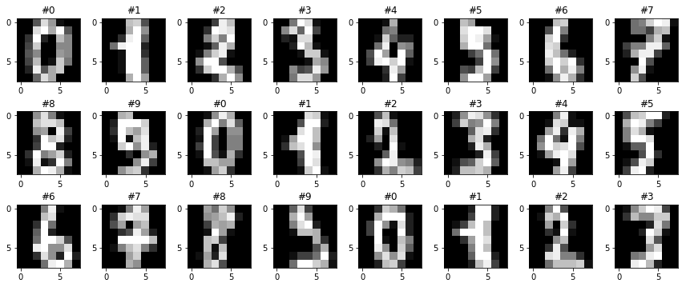

```python
fig, ax = plt.subplots(3, 8, figsize=(12, 5))
for i, axis in zip(range(24), ax.reshape(-1)):
    axis.imshow(X[i,:].reshape(8, 8), cmap='gray')
    axis.set_title('#{}'.format(y[i]))
plt.tight_layout()
```

Amb un nombre tan elevat de dimensions perd sentit visualitzar el dataset amb un *pair plot* i apareixen altres perills com la [maledicció de la dimensionalitat](https://en.wikipedia.org/wiki/Curse_of_dimensionality). Per reduir la seva dimensió i així entendre l'estructura de les dades en alta dimensionalitat hi ha diferents alternatives amb resultats molt diferents.

**Implementació:** Realitzar una reducció de dimensionalitat amb PCA per passar de 64 dimensions a 2 i crear una visualització on el color dels punts depengui del dígit que pertany.

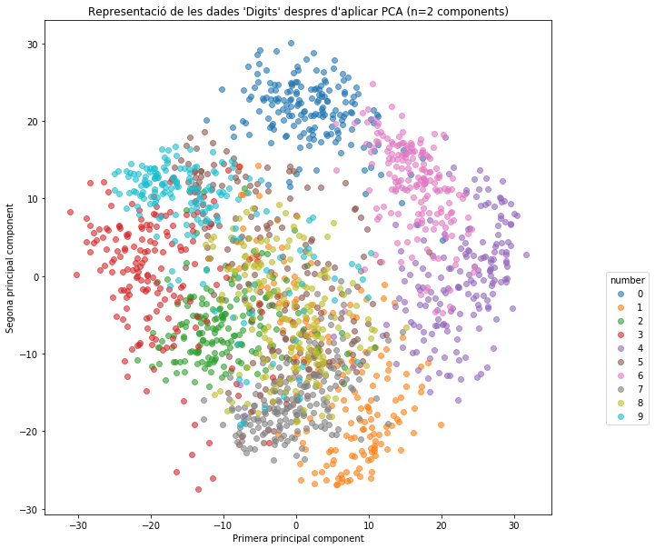

```python
# Reduccio a 2 dimensions utilitzant PCA
pca = PCA(n_components=2)
X_pca = pca.fit_transform(X)

# Dibuixa el resultat d'aplicar el metode PCA
fig,ax = plt.subplots(1,1,figsize=(10,10))

for i in range(len(set(y))):
    ax.scatter(X_pca[y==i][:,0],X_pca[y==i][:,1],label=i,alpha=0.6)

ax.legend(title="number", bbox_to_anchor=(1.2, 0.5))
ax.set_xlabel("Primera principal component")
ax.set_ylabel("Segona principal component")
ax.set_title("Representació de les dades 'Digits' despres d'aplicar PCA (n=2 components)");
```

**Anàlisi:** El resultat de la reducció de dimensionalitat manté la separabilitat? Era d'esperar? Per què?

Es pot veure com, en aquest cas la separabilitat no es manté. Certament es pot veure cert agrupament de determinats nombres, sobretot en la part externa del gràfic, però no hi ha una separabilitat clara i, a més, hi ha la zona central del gràfic on hi ha una barreja de nombres.

El resultat obtingut era d'esperar, ja que si es considera cada pixel de la imatge 8x8 com un atribut, es fa difícil de considerar algun atribut o composició d'atributs que, en funció del seu valor, es pugui classificar correctament el nombre escrit, possiblement, el resultat dependrà de l'estudi d'un conjunt de pixels, sobretot dels situats en la part central de la imatge.

L'algoritme [t-SNE](https://en.wikipedia.org/wiki/T-distributed_stochastic_neighbor_embedding) desenvolupat per [van der Maaten y Hinton](https://lvdmaaten.github.io/tsne/) difereix de PCA en què no tracta de maximitzar la variància explicada. Intuïtivament, t-SNE tracta que el veïnatge d'un punt en baixa dimensionalitat sigui la mateixa que l'original. Partint d'una localització aleatòria de cada punt, corregeix la seva posició de forma iterativa tractant de minimitzar la distància als seus veïns originals fins a convergir.

Per a això, t-SNE disposa de diversos [paràmetres](https://distill.pub/2016/misread-tsne/) que poden modificar dràsticament el resultat. Pel que recomana conèixer el seu funcionament abans d'aplicar la tècnica.

**Implementació:** Realitza una reducció de dimensionalitat amb t-SNE per passar de 64 dimensions a 2 i crea una visualització on el color dels punts depengui del dígit que pertany.

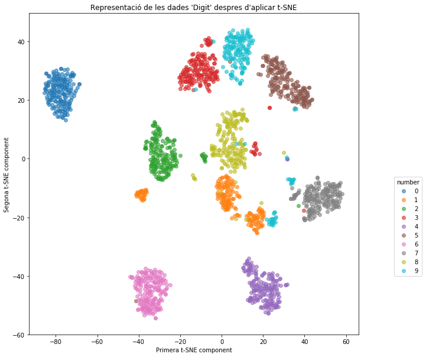

```python
from sklearn.manifold import TSNE

# Reduccio a 2 dimensions utilitzant t-SNE
tsne=TSNE(random_state=6, n_iter=5000, perplexity=50)
X_tsne=tsne.fit_transform(X)

# Dibuixa el resultat d'aplicar el metode t-SNE
fig,ax = plt.subplots(1,1,figsize=(10,10))

for i in range(len(set(y))):
    ax.scatter(X_tsne[y==i][:,0],X_tsne[y==i][:,1],label=i,alpha=0.6)

ax.legend(title="number", bbox_to_anchor=(1.2, 0.5))
ax.set_xlabel("Primera t-SNE component")
ax.set_ylabel("Segona t-SNE component")
ax.set_title("Representació de les dades 'Digit' despres d'aplicar t-SNE");
```

**Anàlisi:** El resultat de la reducció de dimensionalitat manté la separabilitat? Era d'esperar? Per què?

En aquest cas es pot veure com la separabilitat és molt clara, existint determinats grups que es corresponen a diferents nombres. És cert que continuen existint zones on hi ha certa barreja de nombres, en general, es mostra una clara separabilitat.

Era d'esperar el resultat, ja que el mètode cerca una representació en 2D de punts agrupant-los amb similituds per tots els atributs (pixels de la imatge), d'aquesta manera és capaç de trobar patrons de semblança entre les diferents instàncies.

## 4. Aplicació: agrupació de documents (3 punts)

### 4 a. Càrrega i preparació de les dades

En aquest problema s'utilizarà el dataset [*20 news group*](https://archive.ics.uci.edu/ml/machine-learning-databases/20newsgroups-mld/20newsgroups.data.html), amb 20 categories de textos, dels quals se'n seleccionaran 3. L'objectiu és trobar grups de textos (preferiblement de la mateixa categoria) a través de les paraules que els formen.

El primer apartat consisteix en carregar el dataset i preparar les dades (tasca que normalment ocupa entre el 70 i 80% del temps d'un projecte de mineria de dades), en aquest cas els textos.

```python
data = datasets.fetch_20newsgroups(categories=['rec.autos', 'rec.sport.baseball', 'soc.religion.christian'])
texts, targets = data['data'], data['target']
```

On `texts` és una llista amb els articles i `targets` és un vector amb l'índex de la categoria a la que pertany cada text.

La neteja del text hauria de convertir el que tenim inicialment:

```python
print(texts[1])
```

```
From: aas7@po.CWRU.Edu (Andrew A. Spencer)
Subject: Re: Too fast
Organization: Case Western Reserve University, Cleveland, OH (USA)
Lines: 25
Reply-To: aas7@po.CWRU.Edu (Andrew A. Spencer)
NNTP-Posting-Host: slc5.ins.cwru.edu


In a previous article, wrat@unisql.UUCP (wharfie) says:

>In article <1qkon8$3re@armory.centerline.com> jimf@centerline.com (Jim Frost) writes:
>>larger engine.  That's what the SHO is -- a slightly modified family
>>sedan with a powerful engine.  They didn't even bother improving the
>>*brakes.*
>
>	That shows how much you know about anything.  The brakes on the
>SHO are very different - 9 inch (or 9.5? I forget) discs all around,
>vented in front.  The normal Taurus setup is (smaller) discs front,
>drums rear.

one i saw had vented rears too...it was on a lot.
of course, the sales man was a fool..."titanium wheels"..yeah, right..
then later told me they were "magnesium"..more believable, but still
crap, since Al is so m uch cheaper, and just as good....


i tend to agree, tho that this still doesn't take the SHO up to "standard"
for running 130 on a regular basis.  The brakes should be bigger, like
11" or so...take a look at the  ones on the Corrados.(where they have
braking regulations).

DREW
```

en quelcom semblant a:

`In previous article UUCP wharfie says In article centerline com com Jim Frost writes larger engine That's what the SHO is slightly modified family sedan with powerful engine They didn't even bother improving the *brakes That shows how much you know about anything The brakes on the SHO are very different inch or forget discs all around vented in front The normal Taurus setup is smaller discs front drums rear one saw had vented rears too it was on lot of course the sales man was fool titanium wheels yeah right then later told me they were magnesium more believable but still crap since Al is so uch cheaper and just as good tend to agree tho that this still doesn't take the SHO up to standard for running 130 on regular basis The brakes should be bigger like 11 or so take look at the ones on the Corrados where they have braking regulations DREW`

**Implementació:** Neteja els textos, eliminant:

- Les línies de l'encapçalament.
- Els signes de puntuació.
- Els claudàtors, parèntesis i angulars.
- Els salts de línia.
- Exclamacions i interrogacions.
- Els tokens e-mails i de longitud 1.
- Els espais en blanc consecutius.

```python
# En aquest apartat, s'ha utilitzat com referencia l'article:
# https://stackoverflow.com/questions/265960/best-way-to-strip-punctuation-from-a-string-in-python

def netejador_text(text):
    '''
    Funció que "neteja" un text(string) segons el criteri de l'enunciat i retorna un text(string) amb el resultat
    '''
    # Fa una primera neteja esborrant les linies d'encapcalament (com ha requisit es que hi hagui un doble salt de linia)
    # tambe es substitueixen tots els salts de linia per un espai, per tal de poder-los filtrar i eliminar facilment
    text = (text[text.find("\n\n")+2:]).strip().replace("\n"," ").replace("."," ")

    # S'eliminen tots els caracters "especials", basant-nos amb la llista de la biblioteca string.punctuation
    text = text.translate(str.maketrans("", "", "¡!\"#$%&\()*+,-./:;<=>¿?[\\]^_`{|}~\t"))

    # Crea la variable temporal on s'anira guardant el nou text
    text_temp = ""

    # Es cerca per totes les paraules del text (separades per espais)
    for paraula in text.split(" "):
        if (len(paraula)>1) and ("@" not in paraula):              # Es descarten totes les paraules de longitud <1 i
            text_temp += paraula+" "                               # que siguin e-mails (continguin @)

    return text_temp

# Aplica la funcio abans creada a tots els texts de la llista, utilitzant list comprehension
texts=[netejador_text(text) for text in texts]

# Es comprova el resultat obtingut amb el primer text
print(texts[1])
```

[output not shown]

### 4 b. Conversió de textos a vectors

Per tal de trobar grups de textos similars, és necessari convertir cada text a un vector. Existeixen multitud de maneres de fer-ho, una d'elles és aplicar [TF-IDF](https://en.wikipedia.org/wiki/Tf%E2%80%93idf) amb scikit-learn [TfidfVectorizer](http://scikit-learn.org/stable/modules/generated/sklearn.feature_extraction.text.TfidfVectorizer.html), transformant la llista de textos en una [matriu dispersa](https://docs.scipy.org/doc/scipy/reference/sparse.html) amb tantes files com articles i tantes columnes com paraules.

**Implementació:** Transforma els textos a vectors amb TF-IDF. Per a reduïr el número de columnes en la matriu evita les *stop words* en anglès i converteix els textos a minúscules.

```python
from sklearn.feature_extraction.text import TfidfVectorizer

# Inicialitza el transformador tenint en compte els stop words d'angles i convertint els textos a minuscules
vectorizer = TfidfVectorizer(stop_words="english", lowercase=True)

# Entrena i aplica el metode de transformacio en els textos
X = vectorizer.fit_transform(texts)

# Mostra la dimensio de la matriu obtinguda
print(X.shape)
```

```
(1790, 24835)
```

### 4 c. Reducció de la dimensionalitat

Per tal de visualitzar (i, més endavant, identificar els grups de textos semblants), es reduirà ara la dimensionalitat de la matriu anterior. Així, volem que el número de columnes es redueixi a 2, mentre que el número de files es manté, ja que cada fila és un document.

**Implementació:** Utiliza t-SNE per reduïr la dimensionalitat de *n* columnes (paraules) a 2 dimensions. Utilitza un tamany de la perplexitat alt per tal d'augmentar el veïnatge (al voltant de 100).

```python
# Reduccio a 2 dimensions utilitzant t-SNE
tsne=TSNE(random_state=6, n_iter=5000, perplexity=100)           # Inicialitza el model amb els parametres corresponents
X_tsne=tsne.fit_transform(X.toarray())                           # Aplica el model sobre la matriu previament convertida
```

**Implementació:** Visualiza mitjançant un scatter plot els punts en 2 dimensions amb un color diferent per a cada classe.

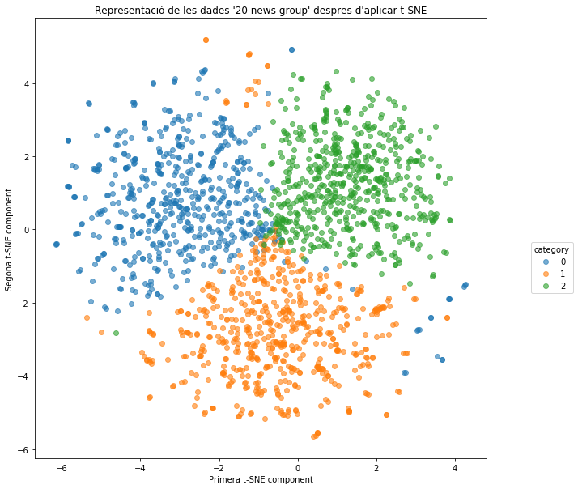

```python
# Dibuixa el resultat d'aplicar el metode t-SNE
fig,ax = plt.subplots(1,1,figsize=(10,10))

for i in range(len(set(targets))):
    ax.scatter(X_tsne[targets==i][:,0],X_tsne[targets==i][:,1],label=i,alpha=0.6)

ax.legend(title="category", bbox_to_anchor=(1.2, 0.5))
ax.set_xlabel("Primera t-SNE component")
ax.set_ylabel("Segona t-SNE component")
ax.set_title("Representació de les dades '20 news group' despres d'aplicar t-SNE");
```

### 4 d. Troba els grups de textos usant diferents algorismes

**Implementació:** Usa *k-means* (amb *k=3*) per identificar els 3 grups d'articles i visualitza el resultat.

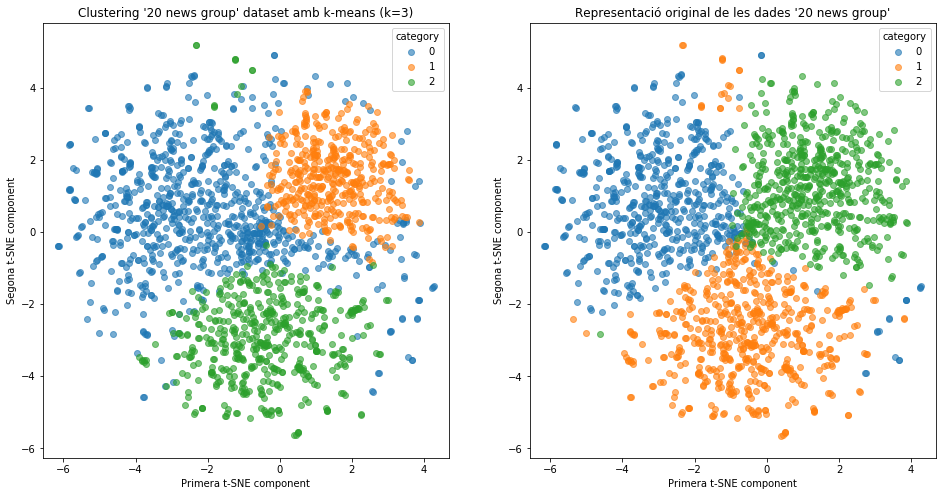

```python
# Implementa el k-means
kmeans = KMeans(n_clusters=3)                 # Inicialitza el model amb el parametre corresponent
kmeans.fit(X)                                 # Calcula el model amb les dades dels documents vectoritzats
y_kmeans = kmeans.predict(X)                  # Assigna a les dades inicials el cluster segons el model calculat
centroides = kmeans.cluster_centers_          # Retorna els centroides dels clusters calculats

# Dibuixa l'agrupacio obtinguda (esquerra) al costat de l'agrupacio original (dreta) en l'espai 2D creat per t-SNE
fig, axes = plt.subplots(1, 2, figsize=(16, 8))

# Mostra l'agrupament resultat d'aplicar k-means
for i in range(len(set(y_kmeans))):
    axes[0].scatter(X_tsne[y_kmeans==i][:,0],X_tsne[y_kmeans==i][:,1],label=i,alpha=0.6)

axes[0].set_xlabel("Primera t-SNE component")
axes[0].set_ylabel("Segona t-SNE component")
axes[0].legend(title="category")
axes[0].axis("equal")
axes[0].set_title("Clustering '20 news group' dataset amb k-means (k=3)")

# Mostra l'agrupament original
for i in range(len(set(targets))):
    axes[1].scatter(X_tsne[targets==i][:,0],X_tsne[targets==i][:,1],label=i,alpha=0.6)

axes[1].legend(title="category")
axes[1].set_xlabel("Primera t-SNE component")
axes[1].set_ylabel("Segona t-SNE component")
axes[1].axis("equal")
axes[1].set_title("Representació original de les dades '20 news group'");
```

**Anàlisi:** Has identificat els 3 grups originals? (el color no té perquè coincidir, només ens importa la forma) Per què?

Tal com es pot observar a les dues figures, tot i que no coincideixen els colors, és a dir, el nombre de l'agrupament resultant, sí que s'observa que el mètode k-means aconsegueix un agrupament força similar a la realitat, únicament a la part central del gràfic és on hi ha més diferència i és on l'agrupament del mètode k-means no acaba de coincidir amb la realitat.

Això succeeix perquè hi ha determinades paraules que són molt característiques i quasi exclusives d'una determinada categoria i, per tant, és d'esperar que el mètode k-means aconsegueixi una bona classificació d'aquests textos. Tot i així, textos amb paraules que no tenen aquesta característica "exclusiva" es fan difícil de classificar amb aquest algoritme.

Per tal d'agrupar els textos tractant de situar els centroides en les regions més denses, [Mean-Shift](http://scikit-learn.org/stable/modules/generated/sklearn.cluster.MeanShift.html) segueix un camí desde qualsevol punt de l'espai guiant-se per la densitat de punts fins a trobar un màxim local (dins de la seva *bandwidth*).

**Implementació:** Usa *Mean-Shift*, canviant la *bandwidth* fins a trobar 3 grups i visualitza el resultat.

```python
from sklearn.cluster import MeanShift

# Clusteritza aplicant Mean-Shift i utilitzant tots els cores de l'ordinador
clustering = MeanShift(bandwidth=1.1,n_jobs=-1)
y_MShift = clustering.fit_predict(X.toarray())

# Mostra les etiquetes resultants d'aplicara l'agrupament
print(set(y_MShift))
```

```
{0}
```

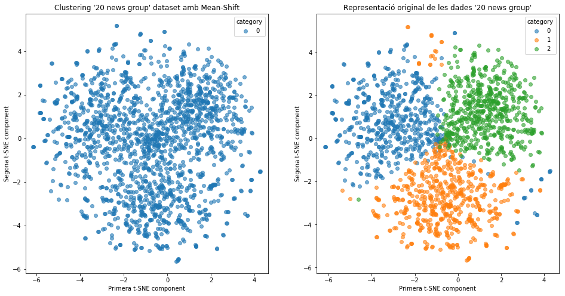

```python
# Dibuixa l'agrupacio obtinguda (esquerra) al costat de l'agrupacio original (esquerra) en l'espai 2D creat per t-SNE
fig, axes = plt.subplots(1, 2, figsize=(16, 8))

# Mostra l'agrupament resultat d'aplicar Mean-Shift
for i in range(len(set(y_MShift))):
    axes[0].scatter(X_tsne[y_MShift==i][:,0],X_tsne[y_MShift==i][:,1],label=i,alpha=0.6)

axes[0].set_xlabel("Primera t-SNE component")
axes[0].set_ylabel("Segona t-SNE component")
axes[0].legend(title="category")
axes[0].axis("equal")
axes[0].set_title("Clustering '20 news group' dataset amb Mean-Shift")

# Mostra l'agrupament original
for i in range(len(set(targets))):
    axes[1].scatter(X_tsne[targets==i][:,0],X_tsne[targets==i][:,1],label=i,alpha=0.6)

axes[1].legend(title="category")
axes[1].set_xlabel("Primera t-SNE component")
axes[1].set_ylabel("Segona t-SNE component")
axes[1].axis("equal")
axes[1].set_title("Representació original de les dades '20 news group'");
```

**Anàlisi:** Has identificat els 3 grups originals? (el color no té perquè coincidir, només ens importa la forma) Per què?

He aplicat l'algoritme Mean-Shift per molts valors de 'bandwidth' i per a cap d'ells he aconseguit un agrupament que identifiqués els 3 grups originals. Sí que he pogut veure que l'algoritme és molt sensible al paràmetre 'bandwidht' emprat, però majoritàriament he passat d'agrupaments d'1 clúster (per bandwidth superiors a 1) a agrupaments de més de 10 clústers (per bandwidth inferiors a 1). Tenint en compte que, tot i utilitzar tots els processadors del portàtil, cada execució de l'algoritme suposa uns 20 minuts, he hagut de desistir en l'intent de trobar un agrupament de 3 clústers.

Em resisteixo a pensar que l'algoritme no és capaç d'aconseguir un clustering correcte, amb el que suposo que, en algun punt m'he equivocat, tot i que no he sabut trobar on, després d'una detallada anàlisis de la implementació realitzada.